# 虚数軸を持つ情報幾何空間

ryamada

2018年4月22日

# 指数型分布族

$$\log{P(x|\theta)} = C(x) + \sum_{i=1} F_i(x) \theta_i - \psi(\theta)$$
# 関数の内積

$$<P_1(x|\theta_1),P_2(x|\theta_2)> = \int P_1(x|\theta_1)P_2(x|\theta_2)dx$$

# 指数型分布族の内積

$$<P_1(x|\theta_1),P_2(x|\theta_2)> = \int P_1(x|\theta_1)P_2(x|\theta_2)dx$$
$$<P_1(x|\theta_1),P_2(x|\theta_2)> = \int e^{\sum_{i=0} F_i(x) \theta_{1,i} - \psi(\theta_1)}e^{\sum_{i=0} F_i(x) \theta_{2,i} - \psi(\theta_2)}dx$$
$$<P_1(x|\theta_1),P_2(x|\theta_2)> = \int e^{\sum_{i=0} F_i(x) (\theta_{1,i}+\theta_{2,i}) - (\psi(\theta_1) + \psi(\theta_2))}dx$$
$$<P_1(x|\theta_1),P_2(x|\theta_2)> = \frac{1}{e^{\psi(\theta_1)}e^{\psi(\theta_2)}} \int e^{\sum_{i=0} F_i(x) (\theta_{1,i}+\theta_{2,i})}dx$$

$$<P_1(x|\theta_1),P_2(x|\theta_2)> = \frac{1}{e^{\psi(\theta_1)}e^{\psi(\theta_2)}} \int e^{\sum_{i=0} F_i(x) \theta_{1+2,i}}dx$$
ただし $\theta_1 + \theta_2 = \theta_{1+2}$.

以下に注意すると
$$\int P(x|\theta_1) dx = \int e^{\sum_{i=0} F_i(x) \theta_{i} - \psi(\theta)} dx = 1\\
\int e^{\sum_{i=0} F_i(x) \theta_{i}} dx = e^{\psi(\theta)}$$

$$<P_1(x|\theta_1),P_2(x|\theta_2)> = \frac{1}{e^{\psi(\theta_1)}e^{\psi(\theta_2)}} \int e^{\sum_{i=0} F_i(x)\theta_{1+2,i}}dx$$
$$<P_1(x|\theta_1),P_2(x|\theta_2)> = \frac{1}{e^{\psi(\theta_1)}e^{\psi(\theta_2)}} \int e^{\sum_{i=0} F_i(x) \theta_{1+2,i} - \psi(\theta_{1+2})}e^{\psi(\theta_{1+2})}dx$$
$$<P_1(x|\theta_1),P_2(x|\theta_2)> = \frac{e^{\psi(\theta_{1+2})}}{e^{\psi(\theta_1)}e^{\psi(\theta_2)}} \int e^{\sum_{i=0} F_i(x) \theta_{1+2,i} - \psi(\theta_{1+2})}dx$$
$$<P_1(x|\theta_1),P_2(x|\theta_2)> = \frac{e^{\psi(\theta_{1+2})}}{e^{\psi(\theta_1)}e^{\psi(\theta_2)}}$$
ここで、指数型分布族のポテンシャル関数 $\psi(\theta)$を天下り式に次のように取ることにする。

$$\psi(\theta) = <\theta,\theta> = \sum_i \theta_i^2$$
そうすると
$$\log{(<P_1(x|\theta_1),P_2(x|\theta_2)>)} = 2 <\theta_1,\theta_2>$$
となる。

この空間での関数間の距離(ダイバージェンス)を
$$<\theta_1-\theta_2,\theta_1-\theta_2> = <\theta_1,\theta_1> + <\theta_2,\theta_2> - 2 <\theta_1,\theta_2>$$
とすることで、この空間における分布間の『距離・ダイバージェンス』も定義できる。

# 標本から関数内積を推定する

標本から関数内積を推定することにすると、このポテンシャル関数条件での$\theta$座標系の内積の推定値が得られることになる。

ただし、以下の例で示すように、この$\theta$座標系の内積・距離は素直なものではない。

純実数の軸と、純虚数の軸とで張られることになる。

純実数の軸においては、値の差が大きければ距離が大きくなり、純虚数の軸では、値の差が小さいほど、距離が大きくなる。

そんな変な空間である。

# やってみよう

```r
n <- 10 # 分布の数
d <- 5 # 項数
library(MCMCpack)
```

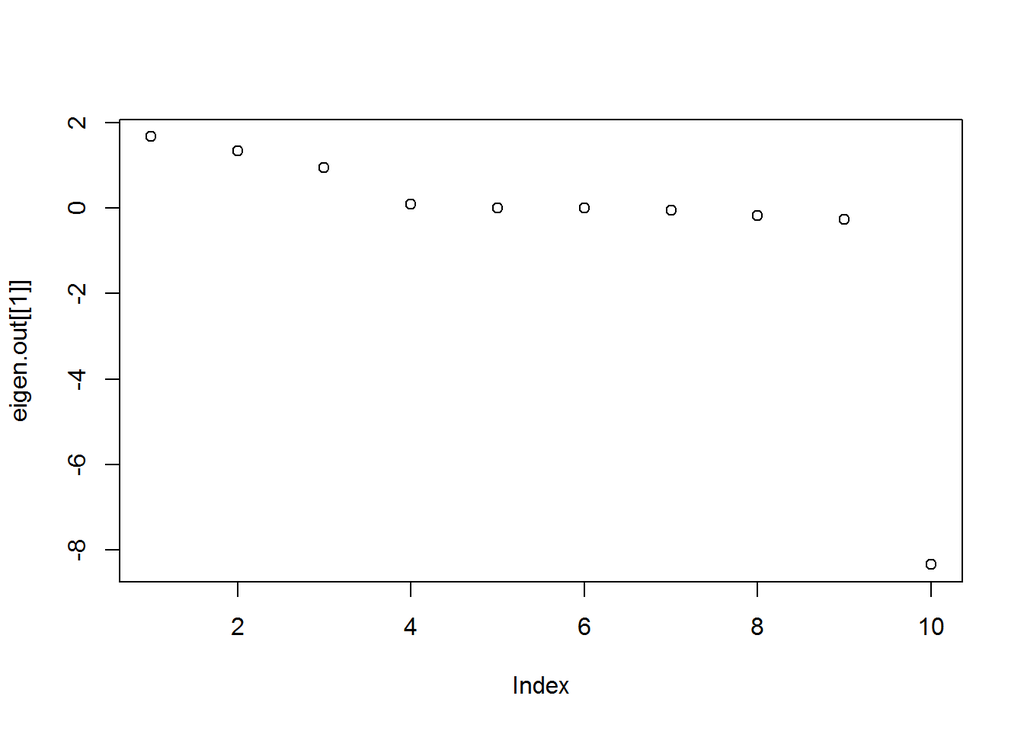

```r
P <- rdirichlet(n,rep(0.6,d))

# log ( 函数内積) / 2 が\theta座標内積であるので、それをペアワイズに求める
H <- log(P %*% t(P)) /2

# 固有値分解する
eigen.out <- eigen(H)
# 正定値ではない
plot(eigen.out[[1]])
```

```r
# このままではうまくないが、むりやり、H = Theta %*% t(Theta) と分解することにする
# 固有ベクトルを並べた行列を複素数行列オブジェクトにする
V <- eigen.out[[2]] + 0*1i
# 固有値の平方根を対角成分にする行列
S <- diag((eigen.out[[1]] + 0*1i)^0.5)
# theta座標を各標本分布に与える
Theta <- V %*% S
# Theta は実・虚混合の座標
print(Theta)
```

```
##                 [,1]           [,2]          [,3]            [,4]
##  [1,]  0.17865061+0i -0.27792616+0i  0.1122475+0i  0.033755096+0i
##  [2,]  0.90244782+0i  0.37686082+0i  0.1616494+0i -0.001076965+0i
##  [3,]  0.07855842+0i -0.51421483+0i -0.1613356+0i  0.023274392+0i
##  [4,] -0.32634565+0i  0.69833542+0i -0.2090495+0i -0.081474182+0i
##  [5,]  0.14502588+0i -0.53576627+0i -0.2611815+0i -0.040943302+0i
##  [6,] -0.45121282+0i  0.18234023+0i -0.2657862+0i  0.134300310+0i
##  [7,] -0.17911189+0i -0.13253857+0i  0.2610976+0i -0.227847757+0i
##  [8,] -0.09999220+0i -0.07829549+0i -0.5106840+0i -0.018706155+0i
##  [9,] -0.60569536+0i -0.13384025+0i  0.5918090+0i  0.066115417+0i
## [10,]  0.28533720+0i  0.08827700+0i  0.1774315+0i  0.106629426+0i
##                   [,5]             [,6]            [,7]          [,8]
##  [1,] -0.0093252949+0i 0+0.03029771585i 0+0.0008452117i 0+0.02437557i
##  [2,] -0.0011630639+0i 0+0.00126480367i 0-0.0483688193i 0-0.01710464i
##  [3,] -0.0047007573+0i 0-0.03940108516i 0-0.0504530007i 0-0.11135731i
```

[output cut: 18 more lines]

```r
# H = Theta %*% t(Theta)の検算
range(Re(Theta%*% t(Theta) -H))
```

```
## [1] -1.443290e-15  4.551914e-15
```

```r
range(Im(Theta%*% t(Theta) -H))
```

```
## [1] 7.954317e-17 1.585385e-16
```

分布型標本にTheta という座標を与えることができた

この座標は一部の軸が実数で

一部の軸が虚数である

実数軸の成分は、値の差が大きいほど、分布間距離は大きく

虚数軸の成分は、値の差が小さいほど、分布間距離は大きい

$log(P) = C(x) + Theta F - \Psi(Theta)$のC,Fを求めたい

```r
logP <- log(P)
Psi <- diag(H)

# C(x):定数項の分をFに組み込むべく、Thetaに1列加える
ThetaC <- cbind(Theta,rep(1,n))
# log(P) = ThetaC %*% F. - \Psi(Theta)
# Fの最下行がC(x)に相当する行

# logP. = log(P) + \Psi(Theta)
logP. <- logP + Psi

# logP. = ThetaC F.
# 一般化逆行列を使って解く

F. <- ginv(ThetaC) %*% logP.

# 検算
range(Mod(logP. - ThetaC %*% F.))
```

```
## [1] 3.470988e-29 1.066218e-14
```

```r
F <- F.[1:(length(F.[,1])-1),]
C <- F.[length(F.[,1]),]

# 検算２

logP.calc <- matrix(rep(C,n),nrow=n,byrow=TRUE) + Theta %*% F - Psi
range(Re(logP.calc))
```

```
## [1] -6.0963762 -0.2932022
```

```r
range(Im(logP.calc)) # 虚部はない
```

```
## [1] -6.896617e-16  6.602351e-16
```

```r
# 一致する
range(Mod(logP - logP.calc))
```

```
## [1] 1.338066e-16 1.066218e-14
```